# Bio 264 Homework #3

Nicholas J. Gotelli

Due: 22 February 2016

Create a new markdown file called `<Your last name>_HW#3_22Feb2016`. Cut and paste the problems below into Markdown, then add chunks of R code to provide your answers. You will turn in both the `.Rmd` and the `.html` file for this homework assignment.

1. Create a function that takes as input an integer value *n*. Inside your function, create a square *n* x *n* matrix and fill it with zeroes. Now replace the diagonal elements with 1s. The function should print the matrix. If you have done this correctly, the 1s should form a visual pattern of an “x” that extends to the 4 corners of the square matrix.
- Try to do this exercise using a `for` loop.

*The key to this problem is to notice that, for any square n x n matrix with row i and column j, we can create an “x” pattern by 1) first filling all of the cases in which i==j and 2) adding a 1 whenever the sum of the row and column coefficients equals the number of rows + 1. We want both conditions, so we need to setup an if statement with the OR operator | to catch both in 1 statement*

```
if (i + j== n + 1 | i==j) m[i,j] <- 1
```

*Now we just insert this into our double `for` loop. To me, this seems much more elegant than the solution below, which requires several steps.*

```r
MyDiag1 <- function(n=5){
  m <- matrix(rep(0,n^2),nrow=n)
  for (i in 1:n){
    for (j in 1:n){
      if(i + j == n + 1 | i==j) m[i,j] <- 1
    }
  }
  return(m)
}
MyDiag1()
```

```
##      [,1] [,2] [,3] [,4] [,5]
## [1,]    1    0    0    0    1
## [2,]    0    1    0    1    0
## [3,]    0    0    1    0    0
## [4,]    0    1    0    1    0
## [5,]    1    0    0    0    1
```

```r
MyDiag1(8)
```

```
##      [,1] [,2] [,3] [,4] [,5] [,6] [,7] [,8]
## [1,]    1    0    0    0    0    0    0    1
## [2,]    0    1    0    0    0    0    1    0
## [3,]    0    0    1    0    0    1    0    0
## [4,]    0    0    0    1    1    0    0    0
## [5,]    0    0    0    1    1    0    0    0
## [6,]    0    0    1    0    0    1    0    0
## [7,]    0    1    0    0    0    0    1    0
## [8,]    1    0    0    0    0    0    0    1
```

- Hunt around on line or in the help system and seem if you can use some of R’s matrix functions to achieve the same thing.

*Here is one way to do this. We first use the `diagonal` function to fill in all the diagonal elements with 1s. Next, we create a matrix z that has the row and column subscripts for the elements with a 1. Next we adjust the z matrix to get the “mirror” column on the other side of the diagonal. Finally, we change those elements in the z matrix from 0 to 1. I have added intermediate print statements so you can see the output at each step, but you would normally strip those out once the code was debugged. This solution works, but I find it a bit cumbersome.*

```r
MyDiag <- function(n=5){
  m <- matrix(rep(0,n^2),nrow=n) # create a square matrix of zeroes
  print(m)                       # print matrix
  diag(m) <- 1                   # fill diagonal elements with 1s
  print(m)                       # print matrix
  z <- which(m==1,arr.ind=TRUE)  # get coefficients for the 1s
  print(z)                       # print coefficient list
  z[,2] <- n + 1 - z[,2]         # set "mirror" element for the columns
  print(z)                       # print modified coefficient list
  m[z] <- 1                      # change the z elements
  return(m)
}

MyDiag()
```

```
##      [,1] [,2] [,3] [,4] [,5]
## [1,]    0    0    0    0    0
## [2,]    0    0    0    0    0
## [3,]    0    0    0    0    0
## [4,]    0    0    0    0    0
## [5,]    0    0    0    0    0
##      [,1] [,2] [,3] [,4] [,5]
## [1,]    1    0    0    0    0
## [2,]    0    1    0    0    0
## [3,]    0    0    1    0    0
## [4,]    0    0    0    1    0
## [5,]    0    0    0    0    1
##      row col
## [1,]   1   1
## [2,]   2   2
## [3,]   3   3
## [4,]   4   4
## [5,]   5   5
##      row col
## [1,]   1   5
## [2,]   2   4
## [3,]   3   3
## [4,]   4   2
## [5,]   5   1
```

```
##      [,1] [,2] [,3] [,4] [,5]
## [1,]    1    0    0    0    1
## [2,]    0    1    0    1    0
## [3,]    0    0    1    0    0
## [4,]    0    1    0    1    0
## [5,]    1    0    0    0    1
```

2. The most basic equation of all is a straight line:

$Y = a + bX$

where *Y* is the “dependent variable”, *X* is the “independent variable”, and *a* and *b* are the constants.

- Using the methods we have developed in class, create a graphic function for examining this linear relationship and illustrate it with different settings for the two parameters. What is the interpretation of the parameters *a* and *b*
- Use this as an opportunity to explore the many options that are available in `par`, and `plot` (or `matplot`). Spiff up your margins, labels, and graphs so they look sharp!

*Here is a simple function for varying the slope, with a few of the many possible parameters illustrated for `mplot`. I then use it to create a 3 panel graph in which I vary the intercept:*

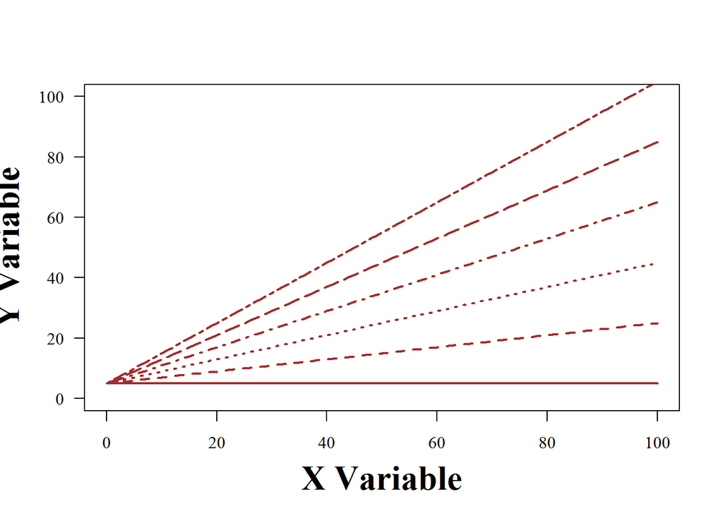

```r
MyLine <- function(a=5,b=seq(0,1,length=6),x=0:100,ylim=c(0,100)){
  m <-matrix(nrow=length(x),ncol=length(b))
 for (i in 1:length(b)){
 y <- a + b[i]*x
 m[,i] <- y
 }




 matplot(x=x,y=m,
      lty=1:length(b),    # uses different line types
      lwd=2,              # increases line thickness
      type="l",           # lines with no points
      pty="s",            # square plotting space
      xlab="X Variable",  #x label
      ylab="Y Variable",  #y label
      ylim=ylim,          #user defined ylimits (adjust for multiple plots)
      las=1,              # plot axis numbers all horizontal
      col="brown",        # change line colors
      cex.lab=2,          # increase label size
      family="serif",     # use serif font for labels
      font.lab=2)         # use boldface for labels
}
MyLine()
```

*And here are 3 panels illustrating variation in both the slope and the intercept:*

```r
opar <- par(no.readonly=TRUE)
par(mfrow=c(1,3))
a <- c(5,20,40) # set different choices for the intercept
for (i in 1:3){
  MyLine(a=a[i],ylim=c(0,140))
}
```

[figure not shown]

```r
  par(opar)
```